# Week 04

Normal distributions

Dr. Peng Zhao

2020-10-07

## Q & A

Q1. Is there a graphic user interface of R for plotting?

A1. Yes. There are many.

```r
# GUI 1. java must be installed before you use this GUI
install.packages(c("JGR","Deducer","DeducerExtras"))
library(JGR)
JGR()

# GUI 2. ggplot must be installed in advance
install.packages("ggplotgui")
library("ggplotgui")
env203 <- read.csv("data/students203.csv")
ggplot_shiny(env203)
```

Q2. Can we have more office hours for Q&A?

A2. Yes. From now on we have flexible office hours. Just come to my office whenever you have questions. An email for an appointment might make sure that I am in office.

## Ice breaking

- Role play: *The Manga Guide to Statistics*: Probability
- Keywords: histogram, density curve, PDF, normal distribution, standard normal distribution, $z$-table

## Objectives

1. Understand the meaning of probability density functions.
2. Know the features of normal distribution.
3. Use standard normal distribution to solve environmental problems.

## Probability Distribution

**Probability Distribution:**

a table, graph, or function that links each outcome of a statistical experiment with the probability of occurrence. Such a function is called Probability Density Function (PDF).

Demo:

LI7500 is a fast response gas analyzer, which can measure the CO<sub>2</sub> concentration at very high frequency. The dataset li7500.csv gives 10000 records of CO<sub>2</sub> concentrations measured in 200 seconds on June 6, 2016, at a field site in Italy.

Use a table, a graph, and a function to describe the distribution of this dataset.

```r
li7500 <- read.csv("data/li7500.csv")
co2 <- li7500[, 1]
```

A table:

```r
range(co2)
```

```
## [1] 385.9590 405.6451
```

```r
co2_group <- cut(co2, 385:406)
table(co2_group)
```

```
## co2_group
## (385,386] (386,387] (387,388] (388,389] (389,390] (390,391] (391,392] (392,393]
##         1         1         3        32        68       160       361       600
## (393,394] (394,395] (395,396] (396,397] (397,398] (398,399] (399,400] (400,401]
##       935      1349      1473      1508      1291      1013       601       346
## (401,402] (402,403] (403,404] (404,405] (405,406]
##       164        64        23         4         3
```

```r
df_co2 <- data.frame(table(co2_group))
df_co2$Percentage <- df_co2$Freq / sum(df_co2$Freq)
```

For example, we can find in this table that $1473 + 1508 = 2981$ observations, or $14.7 \% + 15.1 \% = 29.8 \%$ of the observations appeared between 395 and 397 ppm.

How many observations appeared between 394.5 and 396.5 ppm?

Another table:

```r
co2_group <- cut(co2, seq(385, 406, 0.5))
df_co2 <- data.frame(table(co2_group))
df_co2$Percentage <- df_co2$Freq / sum(df_co2$Freq)
```

we can find in this new table that $711 + 697 + 776 + 786 = 2970$ observations, or $7.11 \% + 6.97 \% + 7.76 \% + 7.86 \% = 29.7 \%$ of the observations appeared between 394.5 and 397 ppm.

Then how many observations appeared between 394.25 and 396.25 ppm? Or 394.0625 and 396.0625?

A very long table might answer these two questions, but more questions will require a much longer table and it never ends.

A graph might be better.

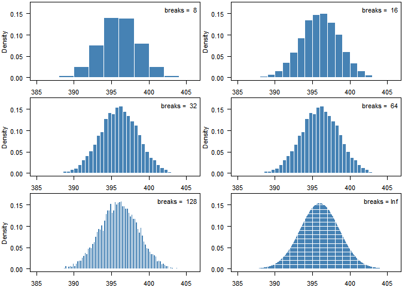

Graphs that describe the distribution of CO2 concentration

The shaded areas are the percentages. The smaller bin width (the more breaks) we use, the more easily we can answer the previous questions. When the bin width (range of class) in a histogram is decreased to the limit at zero, i.e. the bin number is increased to infinity, the histogram eventually becomes a curved line, and we can know how many observations between any two given numbers.

We can also use a function to describe this curve. Such a function is a Probability Density Function (PDF). In this case, this curve can be described in a normal distribution function.

## Normal Distribution

The PDF of the normal distribution (sometimes called the Gaussian distribution) is:

$$f(x)=\frac{1}{\sigma\sqrt{2 \pi}} e^{-\frac{1}{2}(\frac{x-\mu}{\sigma})^{2} }$$
In the case of the CO<sub>2</sub> data:

```r
mu <-  mean(co2)
mu
```

```
## [1] 396.0016
```

```r
n <- length(co2)
sigma <- sd(co2) * sqrt((n-1)/n)
sigma
```

```
## [1] 2.579715
```

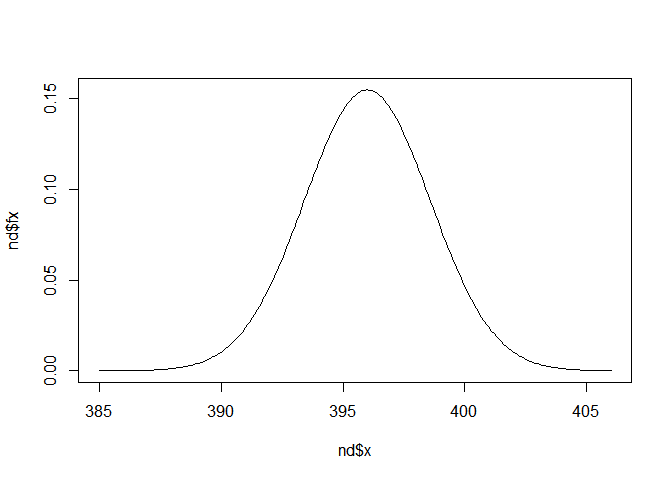

```r
nd <- data.frame(x = seq(385, 406, 0.1))
nd$fx <- 1 /  (sigma * sqrt(2 * 3.14)) *
  exp(-(nd$x - mu)^2 / (2 * sigma ^ 2 ))

plot(nd$x, nd$fx, type = "l")
```

f(x) is the density shown in previous graphs. we need to depend on concepts introduced in basic calculus to describe these distributions.

$$P(x_1 < x < x_2) = \int_{x_1}^{x_2} f(x)\text d x = \int_{x_1}^{x_2}\frac{1}{\sigma\sqrt{2 \pi}} e^{-\frac{1}{2}(\frac{x-\mu}{\sigma})^{2} } \text d x$$

For example, how many observations appeared between 394.0625 and 396.0625?

```r
p395 <- pnorm(395, mean = mu, sd = sigma)
p397 <- pnorm(397, mean = mu, sd = sigma)
p397 - p395
```

```
## [1] 0.3017173
```

```r
p394.5 <- pnorm(394.5, mean = mu, sd = sigma)
p396.5 <- pnorm(396.5, mean = mu, sd = sigma)
p396.5 - p394.5
```

```
## [1] 0.2963413
```

```r
p394.0625 <- pnorm(c(394.0625), mean = mu, sd = sigma)
p396.0625 <- pnorm(c(396.0625), mean = mu, sd = sigma)
p396.0625 - p394.0625
```

```
## [1] 0.2832912
```

The PDF of the normal distribution has the following features:

- It is bell shaped and symmetrical about its mean $\mu$.
- The mean, median and mode are all equal.
- The total area under the curve is one unit.
- Approximately 68%, 95% and 99.7% of the area is within 1, 2 and 3 standard deviations from the mean.
- It is completely determined by the parameters $\mu$ and $\sigma$.
- Different values of $\mu$ shift the graph along the horizontal axis. Different values of $\sigma$ alter the degree of flatness and peakedness of the curve. This is the reason why $\mu$ is known as the location parameter and $\sigma$ as the shape parameter.
- The probability between two values $a$ and $b$ may be expressed as $P(a<X<b) = \int_a^bf(x)\text dx$, which confirms that $P(X=c) = \int_c^cf(x)\text dx = 0$.

Demo:

The height in the ENV203 students data.

1. Create a table, showing the distribution of the height, including the frequency and relative frequency (percentage) of the students in the range of 150 ~ 155, 155 ~ 160, 160 ~ 165, 165 ~ 170, 170 ~ 175, 175 ~ 180, 180 ~ 185, 185 ~ 190 cm. How many students are over 170 cm?
2. Plot a histogram for the height. Is it a normal distribution?
3. Estimate the percentage of students between 162 and 172 cm with the PDF. Double check your answer with the real dataset.
1. Frequency table

```r
env203 <- read.csv("data/students203.csv")
h <- env203$Height
range(h)
```

```
## [1] 150 186
```

```r
h_group <- cut(h, seq(150, 190, 5), right = FALSE)
table(h_group)
```

```
## h_group
## [150,155) [155,160) [160,165) [165,170) [170,175) [175,180) [180,185) [185,190)
##         2         3         7        15        13         8         1         1
```

```r
df_h <- data.frame(table(h_group))
df_h$Percentage <- df_h$Freq / sum(df_h$Freq)
df_h
```

```
##     h_group Freq Percentage
## 1 [150,155)    2       0.04
## 2 [155,160)    3       0.06
## 3 [160,165)    7       0.14
## 4 [165,170)   15       0.30
## 5 [170,175)   13       0.26
## 6 [175,180)    8       0.16
## 7 [180,185)    1       0.02
## 8 [185,190)    1       0.02
```

2. Graph

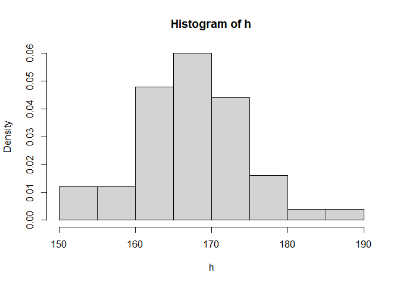

```r
hist(h, freq = FALSE)
```

How do you know whether it is a normal distribution?

Method 1: Visualized it with a histogram + density curve + normal distribution curve. Find if it is bell shaped with one single symmetrical peak and the mean close to the median.

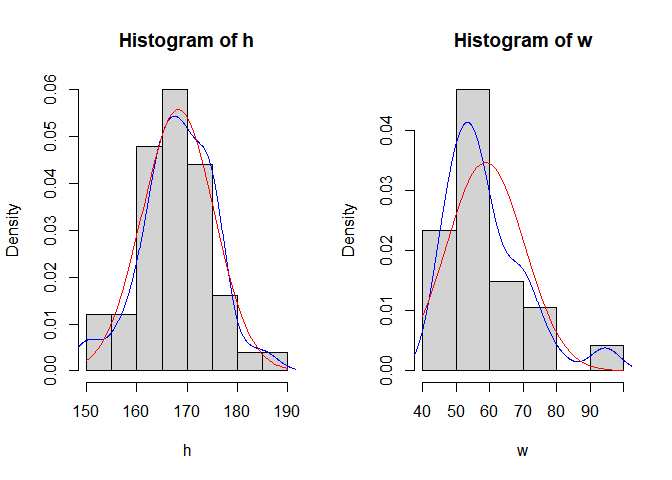

```r
par(mfrow = c(1,2))
hist(h, freq = FALSE)
lines(density(h), col = "blue")
curve(dnorm(x, mean = mean(h),
            sd = sd(h)*sqrt((length(h)-1)/length(h))),
      add = TRUE, col = "red")

w <- env203$Weight[!is.na(env203$Weight)]
hist(w, freq = FALSE)
lines(density(w), col = "blue")
curve(dnorm(x, mean = mean(w),
            sd = sd(w)*sqrt((length(w)-1)/length(w))),
      add = TRUE, col = "red")
```

Method 2: QQ plot. Find if the data points are close to the line of the perfect normal distribution with no obvious pattern coming away from the line.

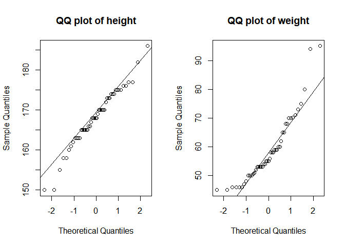

```r
par(mfrow = c(1,2))
qqnorm(h, main = "QQ plot of height")
qqline(h)

qqnorm(w, main = "QQ plot of weight")
qqline(w)
```

Method 3: Shapiro-Wilk’s W test. We assume the normal distribution as the null hypothesis ($H_0$). If $p < 0.05$, we can reject $H_0$, i.e. normality cannot be assumed at a 95% confidence level.

```r
shapiro.test(h)
```

```
##
##  Shapiro-Wilk normality test
##
## data:  h
## W = 0.97553, p-value = 0.3823
```

```r
shapiro.test(w)
```

```
##
##  Shapiro-Wilk normality test
##
## data:  w
## W = 0.87987, p-value = 0.0001744
```

3. PDF

```r
mu <- mean(h)
mu
```

```
## [1] 168.22
```

```r
n <- length(h)
sigma <- sd(h) * sqrt((n-1)/n)
sigma
```

```
## [1] 7.150636
```

$$P(162 < x < 172) = \int_{162}^{172} f(x)\text d x = \int_{x_1}^{x_2}\frac{1}{\sigma\sqrt{2 \pi}} e^{-\frac{1}{2}(\frac{x-\mu}{\sigma})^{2} } \text d x= \int_{162}^{172}\frac{1}{7.15 \times \sqrt{2 \pi }} e^{-\frac{1}{2}(\frac{x-168}{7.15})^{2} } \text d x$$

```r
p172 <- pnorm(172, mean = mu, sd = sigma)
p162 <- pnorm(162, mean = mu, sd = sigma)
p172 - p162
```

```
## [1] 0.5092765
```

```r
sum(h > 162 & h < 172) / n
```

```
## [1] 0.5
```

What if I cannot use R for these estimations?

## Standard Normal Distribution

In the special case of $\mu=0$ and $\sigma = 1$ in a normal distribution, it is called the standard normal distribution or the unit normal distribution .

$$f(x)=\frac{1}{\sigma\sqrt{2 \pi}} e^{-\frac{1}{2}(\frac{x-\mu}{\sigma})^{2} }$$

$$f(z)=\frac{1}{\sqrt{2 \pi }} e^{-\frac{1}{2}z^{2}}$$
You can look up the $z$ table for the probability in a standard normal distribution.

z table

|  | 0 | 0.01 | 0.02 | 0.03 | 0.04 | 0.05 | 0.06 | 0.07 | 0.08 | 0.09 |
| --- | --- | --- | --- | --- | --- | --- | --- | --- | --- | --- |
| -3.4 | 0.0003 | 0.0003 | 0.0003 | 0.0003 | 0.0003 | 0.0003 | 0.0003 | 0.0003 | 0.0003 | 0.0002 |
| -3.3 | 0.0005 | 0.0005 | 0.0005 | 0.0004 | 0.0004 | 0.0004 | 0.0004 | 0.0004 | 0.0004 | 0.0003 |
| -3.2 | 0.0007 | 0.0007 | 0.0006 | 0.0006 | 0.0006 | 0.0006 | 0.0006 | 0.0005 | 0.0005 | 0.0005 |
| -3.1 | 0.0010 | 0.0009 | 0.0009 | 0.0009 | 0.0008 | 0.0008 | 0.0008 | 0.0008 | 0.0007 | 0.0007 |
| -3.0 | 0.0013 | 0.0013 | 0.0013 | 0.0012 | 0.0012 | 0.0011 | 0.0011 | 0.0011 | 0.0010 | 0.0010 |
| -2.9 | 0.0019 | 0.0018 | 0.0018 | 0.0017 | 0.0016 | 0.0016 | 0.0015 | 0.0015 | 0.0014 | 0.0014 |
| -2.8 | 0.0026 | 0.0025 | 0.0024 | 0.0023 | 0.0023 | 0.0022 | 0.0021 | 0.0021 | 0.0020 | 0.0019 |
| -2.7 | 0.0035 | 0.0034 | 0.0033 | 0.0032 | 0.0031 | 0.0030 | 0.0029 | 0.0028 | 0.0027 | 0.0026 |
| -2.6 | 0.0047 | 0.0045 | 0.0044 | 0.0043 | 0.0041 | 0.0040 | 0.0039 | 0.0038 | 0.0037 | 0.0036 |
| -2.5 | 0.0062 | 0.0060 | 0.0059 | 0.0057 | 0.0055 | 0.0054 | 0.0052 | 0.0051 | 0.0049 | 0.0048 |
| -2.4 | 0.0082 | 0.0080 | 0.0078 | 0.0075 | 0.0073 | 0.0071 | 0.0069 | 0.0068 | 0.0066 | 0.0064 |
| -2.3 | 0.0107 | 0.0104 | 0.0102 | 0.0099 | 0.0096 | 0.0094 | 0.0091 | 0.0089 | 0.0087 | 0.0084 |
| -2.2 | 0.0139 | 0.0136 | 0.0132 | 0.0129 | 0.0125 | 0.0122 | 0.0119 | 0.0116 | 0.0113 | 0.0110 |
| -2.1 | 0.0179 | 0.0174 | 0.0170 | 0.0166 | 0.0162 | 0.0158 | 0.0154 | 0.0150 | 0.0146 | 0.0143 |
| -2.0 | 0.0228 | 0.0222 | 0.0217 | 0.0212 | 0.0207 | 0.0202 | 0.0197 | 0.0192 | 0.0188 | 0.0183 |
| -1.9 | 0.0287 | 0.0281 | 0.0274 | 0.0268 | 0.0262 | 0.0256 | 0.0250 | 0.0244 | 0.0239 | 0.0233 |
| -1.8 | 0.0359 | 0.0351 | 0.0344 | 0.0336 | 0.0329 | 0.0322 | 0.0314 | 0.0307 | 0.0301 | 0.0294 |
| -1.7 | 0.0446 | 0.0436 | 0.0427 | 0.0418 | 0.0409 | 0.0401 | 0.0392 | 0.0384 | 0.0375 | 0.0367 |
| -1.6 | 0.0548 | 0.0537 | 0.0526 | 0.0516 | 0.0505 | 0.0495 | 0.0485 | 0.0475 | 0.0465 | 0.0455 |
| -1.5 | 0.0668 | 0.0655 | 0.0643 | 0.0630 | 0.0618 | 0.0606 | 0.0594 | 0.0582 | 0.0571 | 0.0559 |
| -1.4 | 0.0808 | 0.0793 | 0.0778 | 0.0764 | 0.0749 | 0.0735 | 0.0721 | 0.0708 | 0.0694 | 0.0681 |
| -1.3 | 0.0968 | 0.0951 | 0.0934 | 0.0918 | 0.0901 | 0.0885 | 0.0869 | 0.0853 | 0.0838 | 0.0823 |
| -1.2 | 0.1151 | 0.1131 | 0.1112 | 0.1093 | 0.1075 | 0.1056 | 0.1038 | 0.1020 | 0.1003 | 0.0985 |
| -1.1 | 0.1357 | 0.1335 | 0.1314 | 0.1292 | 0.1271 | 0.1251 | 0.1230 | 0.1210 | 0.1190 | 0.1170 |
| -1.0 | 0.1587 | 0.1562 | 0.1539 | 0.1515 | 0.1492 | 0.1469 | 0.1446 | 0.1423 | 0.1401 | 0.1379 |
| -0.9 | 0.1841 | 0.1814 | 0.1788 | 0.1762 | 0.1736 | 0.1711 | 0.1685 | 0.1660 | 0.1635 | 0.1611 |
| -0.8 | 0.2119 | 0.2090 | 0.2061 | 0.2033 | 0.2005 | 0.1977 | 0.1949 | 0.1922 | 0.1894 | 0.1867 |
| -0.7 | 0.2420 | 0.2389 | 0.2358 | 0.2327 | 0.2296 | 0.2266 | 0.2236 | 0.2206 | 0.2177 | 0.2148 |
| -0.6 | 0.2743 | 0.2709 | 0.2676 | 0.2643 | 0.2611 | 0.2578 | 0.2546 | 0.2514 | 0.2483 | 0.2451 |
| -0.5 | 0.3085 | 0.3050 | 0.3015 | 0.2981 | 0.2946 | 0.2912 | 0.2877 | 0.2843 | 0.2810 | 0.2776 |
| -0.4 | 0.3446 | 0.3409 | 0.3372 | 0.3336 | 0.3300 | 0.3264 | 0.3228 | 0.3192 | 0.3156 | 0.3121 |
| -0.3 | 0.3821 | 0.3783 | 0.3745 | 0.3707 | 0.3669 | 0.3632 | 0.3594 | 0.3557 | 0.3520 | 0.3483 |
| -0.2 | 0.4207 | 0.4168 | 0.4129 | 0.4090 | 0.4052 | 0.4013 | 0.3974 | 0.3936 | 0.3897 | 0.3859 |
| -0.1 | 0.4602 | 0.4562 | 0.4522 | 0.4483 | 0.4443 | 0.4404 | 0.4364 | 0.4325 | 0.4286 | 0.4247 |
| -0.0 | 0.5000 | 0.4960 | 0.4920 | 0.4880 | 0.4840 | 0.4801 | 0.4761 | 0.4721 | 0.4681 | 0.4641 |
| 0.0 | 0.5000 | 0.5040 | 0.5080 | 0.5120 | 0.5160 | 0.5199 | 0.5239 | 0.5279 | 0.5319 | 0.5359 |
| 0.1 | 0.5398 | 0.5438 | 0.5478 | 0.5517 | 0.5557 | 0.5596 | 0.5636 | 0.5675 | 0.5714 | 0.5753 |
| 0.2 | 0.5793 | 0.5832 | 0.5871 | 0.5910 | 0.5948 | 0.5987 | 0.6026 | 0.6064 | 0.6103 | 0.6141 |
| 0.3 | 0.6179 | 0.6217 | 0.6255 | 0.6293 | 0.6331 | 0.6368 | 0.6406 | 0.6443 | 0.6480 | 0.6517 |
| 0.4 | 0.6554 | 0.6591 | 0.6628 | 0.6664 | 0.6700 | 0.6736 | 0.6772 | 0.6808 | 0.6844 | 0.6879 |
| 0.5 | 0.6915 | 0.6950 | 0.6985 | 0.7019 | 0.7054 | 0.7088 | 0.7123 | 0.7157 | 0.7190 | 0.7224 |
| 0.6 | 0.7257 | 0.7291 | 0.7324 | 0.7357 | 0.7389 | 0.7422 | 0.7454 | 0.7486 | 0.7517 | 0.7549 |
| 0.7 | 0.7580 | 0.7611 | 0.7642 | 0.7673 | 0.7704 | 0.7734 | 0.7764 | 0.7794 | 0.7823 | 0.7852 |
| 0.8 | 0.7881 | 0.7910 | 0.7939 | 0.7967 | 0.7995 | 0.8023 | 0.8051 | 0.8078 | 0.8106 | 0.8133 |
| 0.9 | 0.8159 | 0.8186 | 0.8212 | 0.8238 | 0.8264 | 0.8289 | 0.8315 | 0.8340 | 0.8365 | 0.8389 |
| 1.0 | 0.8413 | 0.8438 | 0.8461 | 0.8485 | 0.8508 | 0.8531 | 0.8554 | 0.8577 | 0.8599 | 0.8621 |
| 1.1 | 0.8643 | 0.8665 | 0.8686 | 0.8708 | 0.8729 | 0.8749 | 0.8770 | 0.8790 | 0.8810 | 0.8830 |
| 1.2 | 0.8849 | 0.8869 | 0.8888 | 0.8907 | 0.8925 | 0.8944 | 0.8962 | 0.8980 | 0.8997 | 0.9015 |
| 1.3 | 0.9032 | 0.9049 | 0.9066 | 0.9082 | 0.9099 | 0.9115 | 0.9131 | 0.9147 | 0.9162 | 0.9177 |
| 1.4 | 0.9192 | 0.9207 | 0.9222 | 0.9236 | 0.9251 | 0.9265 | 0.9279 | 0.9292 | 0.9306 | 0.9319 |
| 1.5 | 0.9332 | 0.9345 | 0.9357 | 0.9370 | 0.9382 | 0.9394 | 0.9406 | 0.9418 | 0.9429 | 0.9441 |
| 1.6 | 0.9452 | 0.9463 | 0.9474 | 0.9484 | 0.9495 | 0.9505 | 0.9515 | 0.9525 | 0.9535 | 0.9545 |
| 1.7 | 0.9554 | 0.9564 | 0.9573 | 0.9582 | 0.9591 | 0.9599 | 0.9608 | 0.9616 | 0.9625 | 0.9633 |
| 1.8 | 0.9641 | 0.9649 | 0.9656 | 0.9664 | 0.9671 | 0.9678 | 0.9686 | 0.9693 | 0.9699 | 0.9706 |
| 1.9 | 0.9713 | 0.9719 | 0.9726 | 0.9732 | 0.9738 | 0.9744 | 0.9750 | 0.9756 | 0.9761 | 0.9767 |
| 2.0 | 0.9772 | 0.9778 | 0.9783 | 0.9788 | 0.9793 | 0.9798 | 0.9803 | 0.9808 | 0.9812 | 0.9817 |
| 2.1 | 0.9821 | 0.9826 | 0.9830 | 0.9834 | 0.9838 | 0.9842 | 0.9846 | 0.9850 | 0.9854 | 0.9857 |
| 2.2 | 0.9861 | 0.9864 | 0.9868 | 0.9871 | 0.9875 | 0.9878 | 0.9881 | 0.9884 | 0.9887 | 0.9890 |
| 2.3 | 0.9893 | 0.9896 | 0.9898 | 0.9901 | 0.9904 | 0.9906 | 0.9909 | 0.9911 | 0.9913 | 0.9916 |
| 2.4 | 0.9918 | 0.9920 | 0.9922 | 0.9925 | 0.9927 | 0.9929 | 0.9931 | 0.9932 | 0.9934 | 0.9936 |
| 2.5 | 0.9938 | 0.9940 | 0.9941 | 0.9943 | 0.9945 | 0.9946 | 0.9948 | 0.9949 | 0.9951 | 0.9952 |
| 2.6 | 0.9953 | 0.9955 | 0.9956 | 0.9957 | 0.9959 | 0.9960 | 0.9961 | 0.9962 | 0.9963 | 0.9964 |
| 2.7 | 0.9965 | 0.9966 | 0.9967 | 0.9968 | 0.9969 | 0.9970 | 0.9971 | 0.9972 | 0.9973 | 0.9974 |
| 2.8 | 0.9974 | 0.9975 | 0.9976 | 0.9977 | 0.9977 | 0.9978 | 0.9979 | 0.9979 | 0.9980 | 0.9981 |
| 2.9 | 0.9981 | 0.9982 | 0.9982 | 0.9983 | 0.9984 | 0.9984 | 0.9985 | 0.9985 | 0.9986 | 0.9986 |
| 3.0 | 0.9987 | 0.9987 | 0.9987 | 0.9988 | 0.9988 | 0.9989 | 0.9989 | 0.9989 | 0.9990 | 0.9990 |
| 3.1 | 0.9990 | 0.9991 | 0.9991 | 0.9991 | 0.9992 | 0.9992 | 0.9992 | 0.9992 | 0.9993 | 0.9993 |
| 3.2 | 0.9993 | 0.9993 | 0.9994 | 0.9994 | 0.9994 | 0.9994 | 0.9994 | 0.9995 | 0.9995 | 0.9995 |
| 3.3 | 0.9995 | 0.9995 | 0.9995 | 0.9996 | 0.9996 | 0.9996 | 0.9996 | 0.9996 | 0.9996 | 0.9997 |
| 3.4 | 0.9997 | 0.9997 | 0.9997 | 0.9997 | 0.9997 | 0.9997 | 0.9997 | 0.9997 | 0.9997 | 0.9998 |

How to read the $z$ table:

- The probability for $z < -1$ is 0.1587.
- The probability for $z < 1.53$ is 0.9370.
- The probability for $-1 < z < 1.53$ is $0.9370 - 0.1587 = 0.7783$.

[figure not shown]

z distribution

The PDF of the standard normal distribution has the following features:

- It is bell shaped and symmetrical about its mean $\mu$.
- The mean, median and mode are all 0.
- The total area under the curve is one unit.
- Approximately 68%, 95% and 99.7% of the area is within $\pm 1$, $\pm 2$ and $\pm 3$, respectively.
- The probability between two values $a$ and $b$ ($P(a<X<b)$) in a normal distribution equals to the probability between $\frac{a-\mu}{\sigma}$ and $\frac{b-\mu}{\sigma}$ in a standard normal distribution.

If a quantitative variable $x$ has a normal distribution with the mean of $\mu$ and standard deviation of $\sigma$, then we can create a new variable $z_\mathrm {score}=(x-\mu)/\sigma$, and $z_\mathrm {score}$ has a standard normal distribution.

For example, we convert a normal distribution into a standard normal distribution for the height data:

```r
z_score <- (h - mu) /sigma
z_score
```

```
##  [1] -0.03076649 -2.54802498 -0.73000496 -1.42924343  0.94816736  1.22786275
##  [7]  0.66847198  1.08801506  0.24892889  2.48649199  0.24892889  0.80831967
## [13]  0.66847198 -0.73000496  0.94816736 -2.54802498  0.24892889 -1.14954804
## [19]  0.24892889  0.52862428  1.22786275  0.94816736 -0.03076649 -0.31046188
## [25] -1.00970035 -0.73000496  0.10908120 -0.45030957  0.80831967 -0.31046188
## [31]  0.24892889 -0.45030957 -1.84878651  0.80831967 -0.45030957 -0.45030957
## [37] -0.03076649 -0.45030957 -0.45030957 -1.42924343 -0.17061419 -0.03076649
## [43]  0.66847198  1.92710122 -0.73000496 -0.86985265 -0.03076649  0.24892889
## [49]  0.94816736  1.08801506
```

```r
mean(z_score)
```

```
## [1] 1.555266e-16
```

```r
sd(z_score)
```

```
## [1] 1.010153
```

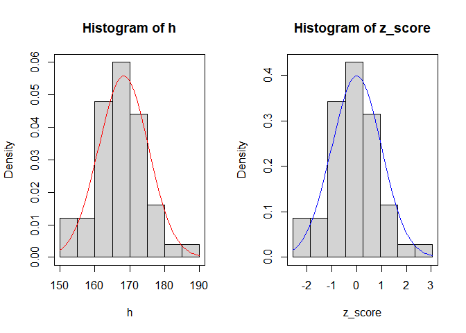

Convert a normal distribution into a standard normal distribution

```r
par(mfrow = c(1,2))

hist(h, freq = FALSE, breaks = seq(150, 190, 5))
curve(dnorm(x, mu, sigma), col = "red", add = TRUE)
box()

hist(z_score, freq = FALSE, breaks = (seq(150, 190, 5) - mu)/sigma)
curve(dnorm(x, 0, 1), col = "blue", add = TRUE)
box()
```

If we want to know the percentage of the frequency in the range between two given values of the height ($h_1$ and $h_2$), we can convert the height values into $z$ ($z_1$ and $z_2$), and look them up in the $z$ table.

Demo:

The height in the ENV203 students data.

Estimate the percentage of students between 162 and 172 cm with the $z$ table.

```r
mu <- mean(h)
n <- length(h)
sigma <- sd(h) * sqrt((n-1) /n)
(162 - mu)/sigma
```

```
## [1] -0.8698527
```

```r
# look up the z table. -0.87 ---- 0.1922
(172 - mu)/sigma
```

```
## [1] 0.5286243
```

```r
# look up the z table. 0.53 ---- 0.7019
0.7019 - 0.1922
```

```
## [1] 0.5097
```

The probability of $\mu - z_0\sigma < x < \mu + z_0\sigma$ (or $\mu \pm z_0\sigma$) in the normal distribution of $x$ equals to the probability of $-z_0 < z < z_0$ in the standard normal distribution of $z$. In this way, we can get the percentage (possibility) of any given range in a normal distribution by simple arithmetic calculation and the $z$ table.

## Assignments

- Role play by a randomly chosen group: *The Manga Guide to Statistics*: Standard Score
- Read: Normal Distribution
- Read: QQ plot

## Exercises

**Rui and Ramen**

Rui loves ramen (noodles). She found the noodle price in all the noodle shops in a shpping mall follows a normal distribution with the mean of 750 YEN and standard deviation of 80 YEN.

1. What is relative frequency (percentage) of the noodles with the price lower than 550 YEN?
2. What is relative frequency of the noodles with the price between 600 and 680 YEN?
3. What is relative frequency of the noodles with the price over 900 YEN?
4. Create a table, showing the relative frequencies in the bins of < 600, 600 – 650, 650 – 700, 700 – 750, 750 - 800, 800 –850, 850 – 900, > 900 Yen.

**Students body temperature**

Use the body temperature data in the ENV203 students data.

1. Create a table, showing the distribution of the temperature, including the frequency and percentage of the students with the breaks at 36, 36.1, 36.2, 36.3, 36.4, 36.5, 36.6, 36.7, 36.8 $^\circ$C. How many students had the temperature below 36.4 $^\circ$C?
2. Plot a histogram for the body temperature. Is it a normal distribution?

**Penguins flipper length**

The dataset *penguins* includes measurements for penguin species one three islands in Palmer Archipelago, Antarctica. There are eight variables: penguin species, island, bill length (millimeters), bill depth (millimeters), flipper length (millimeters), body mass (grams), sex (female, male), and the study year. This exercise deals with the flipper length of Chinstrap only.

Download the penguins.csv data file from the Learning Mall.

1. Create a table, showing the distribution of the Chinstrap’s flipper length, including the frequency and relative frequency (percentage) of the subjects with the breaks at 175, 180, 185, 190, 195, 200, 205, 210, 215 mm. How many Chinstraps have the flipper length below 190 mm?
2. Plot a histogram for the flipper length of Chinstrap. Is it a normal distribution?
3. Suppose it follows the normal distribution. Estimate the relative frequency (percentage) of the Chinstraps with the flipper length between 203 and 208 mm with the PDF.
4. Estimate the relative frequency (percentage) of the Chinstraps with flipper length between 203 and 208 mm using the $z$ table.